# STAT 687 - Chapter 2

Models, Censoring & Likelihood for Failure-Time Data

Maj Jason Freels

Air Force Institute of Technology

## This chapter explains

STAT 687 - Chapter 2

- Models for continuous failure-time processes
- Models used for the discrete data from these continuous failure-time processes
- Common censoring mechanisms that restrict our ability to observe all of the failure times that might occur in a reliability study
- Principles of likelihood and how likelihood relates to the probability of the observed data
- How likelihood ideas can be used to make inferences from reliability data

# Section 2.1|Models for Continuous Failure Time Processes

## $\S$ 2.1.1 - Failure time distribution functions

STAT 687 - Chapter 2

**Chapter 1 presented:**

- Examples of time-to-failure data for different types of systems
- A strategy for estimating system performance metrics from the data

The most common reliability metric is the failure-time distribution

Most failure time processes are modeled using a continuous scale

- Time: seconds or years
- Distance: feet or miles

This course will focus on continuous random variables with “lifetime” distributions, i.e. $(T\in \mathcal{R}^{+}),$

## $\S$ 2.1.1 - Failure time distribution functions

STAT 687 - Chapter 2

For $(T\in \mathcal{R}^{+}),$ the following probability functions will be used in this course

$\hspace{12pt}F(t)$ - Cumulative density function (CDF)

$\hspace{14pt}f(t)$ - Probability density function (pdf)

$\hspace{13pt}S(t)$ - Reliability (survivor) function

$\hspace{14pt}h(t)$ - Hazard rate (failure rate) function

$\hspace{11pt}H(t)$ - Cumulative hazard function

$F^{-1}(p)$ - Inverse CDF (or quantile function)

## The cumulative density function - $F(t)$

STAT 687 - Chapter 2

For the random variable $T\in \mathcal{R}^{+}$

- The cdf is a strictly positive, non-decreasing function relating the probability that the true (but unknown) value of $T$ is less than or equal to $t$

$F(t)=Pr(T\le t), t\in (0,\infty)$

- Where

  $F(t) \ge 0, \forall t \in \mathcal{R}^{+}$

  $F(0)=0$

  $\displaystyle \lim_{t \to \infty} F(t)=1$

## The probability density function - $f(t)$

STAT 687 - Chapter 2

[interactive chart not shown]

For the random variable $T\in \mathcal{R}^{+}$

- The pdf relates the possible values of $T$ to their respective relative probabilities of occurrence

$f(t)=Pr(T=t), t\in (0,\infty)$

- Where

  $F(0)=0$

  $f(t)=\displaystyle \frac{dF(t)}{dt}=-\displaystyle \frac{dR(t)}{dt}$

  $F(t)= \displaystyle \int_0^t f(t)dt$

## The survival (reliability) function - $S(t)$

STAT 687 - Chapter 2

For the random variable $T\in \mathcal{R}^{+}$

- The survival function is a strictly positive, non-increasing function relating the probability that the true (but unknown) value of $T$ is greater than $t$

$S(t)=Pr(T > t), t\in (0,\infty)$

- Where

  $S(t) \ge 0, \forall t \in \mathcal{R}^{+}$

  $S(0)=1$

  $\displaystyle \lim_{t \to \infty} S(t)=0$

## The hazard (failure rate) function - $h(t)$

STAT 687 - Chapter 2

For the random variable $T\in \mathcal{R}^{+}$

- The hazard function relates the instantaneous, conditional probability of failure in the interval $(t+\Delta t)$ given $T>t$

$\begin{aligned} h(t)&=\displaystyle \lim_{\Delta t \to 0} \frac{Pr(t < T \le t+\Delta t|T \ge t)}{\Delta t}\\[5mm] &=\displaystyle \lim_{dt \to 0} \frac{R(t)-R(t+dt)}{R(t)dt}\\[5mm] &=\frac{dR(t)}{dt}\frac{1}{R(t)}=\frac{f(t)}{R(t)}\\ \end{aligned}$

## Example probability function plots - Figure 2.1

STAT 687 - Chapter 2

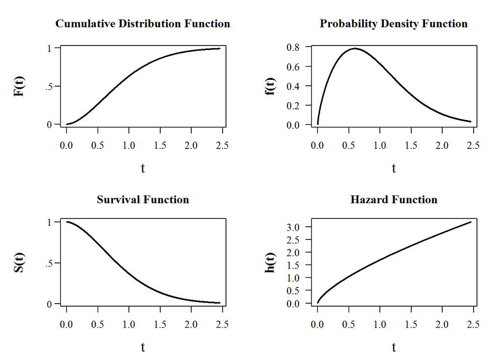

```r
distribution.plot("Weibull",shape=1.7,scale=1,prob.range=c(.000001,.99),my.title="")
```

## Probability function relationships

STAT 687 - Chapter 2

|  | **$F(t)$** | **$f(t)$** | **$S(t)$** | **$h(t)$** |
| --- | --- | --- | --- | --- |
| **$F(t)$** |  | **$\displaystyle\int_0^uf(u)du$** | **$\displaystyle1-F(t)$** | **$\displaystyle 1-\exp\left(-\int_0^u h(u)du\right)$** |
| **$f(t)$** | **$\displaystyle\frac{d}{dt}F(t)$** |  | **$\displaystyle-\frac{d}{dt}F(t)$** | **$\displaystyle h(t)\cdot\exp\left(-\int_0^u h(u)du\right)$** |
| **$S(t)$** | **$\displaystyle1-F(t)$** | **$\displaystyle\int_t^{\infty}f(u)du$** |  | **$\displaystyle\exp\left(-\int_0^u h(u)du\right)$** |
| **$h(t)$** | **$\displaystyle\frac{dF(t)/dt}{1-F(t)}$** | **$\displaystyle\frac{f(t)}{\int_t^{\infty}f(u)du}$** | **$\displaystyle-\frac{d}{dt}\ln F(t)$** |  |

## Bathtub curve hazard function

STAT 687 - Chapter 2

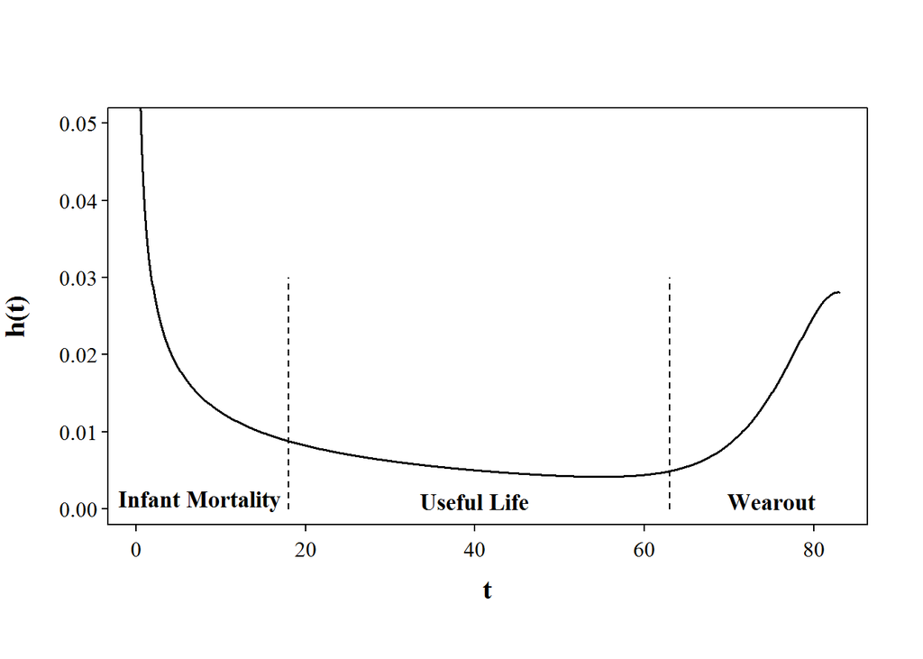

## The cumulative hazard function - $H(t)$

STAT 687 - Chapter 2

$H(t)=\displaystyle \int_{0}^{t} h(t)dx=-\ln[1-F(t)]$

Average hazard rate $T \in (t_1,t_2]$

$AHR(t_1,t_2)=\frac{\int_{t_{1}}^{t_{2}}h(u)du}{t_2-t_1}=\frac{H(t_2)-H(t_1)}{t_2-t_1}$

An important special case arises when $t_1=0$

$AHR(t)=\frac{\int_{0}^{t}h(u)du}{t}=\frac{H(t)}{t}\approx\frac{F(t)}{t}$

Where the approximation is good for $F(t) < 0.10$

## $\S$ 2.1.2 - The quantile function - $t_{p}$

STAT 687 - Chapter 2

The quantile function is the inverse of the cdf, i.e.

$t_{p}=F^{-1}(p)$

Thus, $t_{p}$ corresponds to the time at which $100p%$ of a population will have failed

- If $F(t)$ is strictly increasing, $\exists$ a unique value for $t_{p}$ satisfying $F(t)=p$
- If $F(t)$ is constant over some interval, many values for $t_{p}$ satisfy $F(t)=p$

In general, $t_{p}$ is defined as the *smallest* time $t$ satisfying $F(t)=p$, that is

$t_{p}=\min(t)|P(T\le t)=F(t)\ge p$

## Figure 2.3 - The quantile function is $F^{-1}(p)$

STAT 687 - Chapter 2

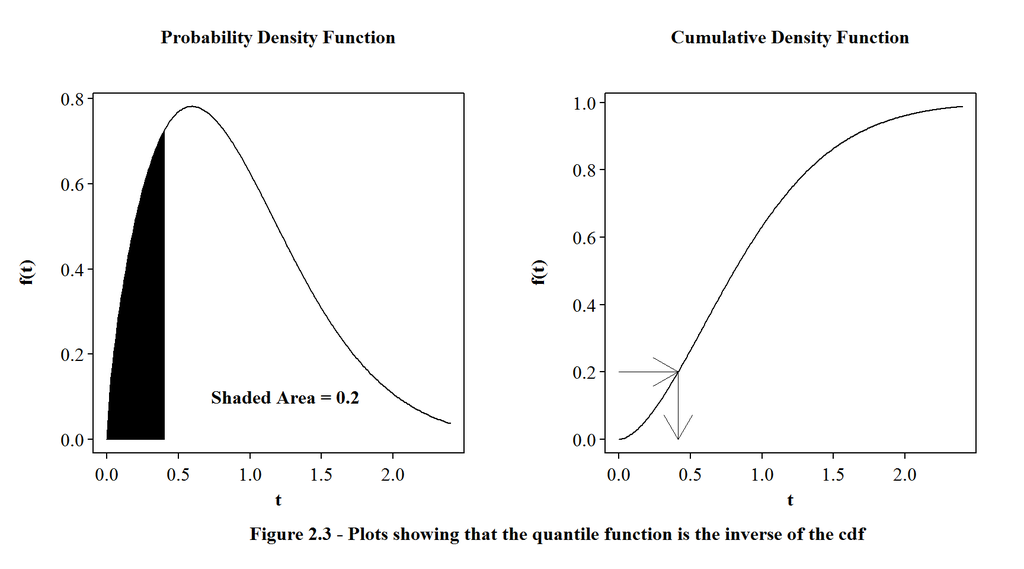

## Figure 2.3 - The quantile function is $F^{-1}(p)$

STAT 687 - Chapter 2

```r
###<b>
par(mfrow=c(1,2),family="serif", font=2,bg=NA)
###</b>
x<-seq(0,2.4,by=.01)
y<-pweibull(seq(0,2.4,by=.01),sh=1.7,sc=1)
z<-dweibull(seq(0,2.4,by=.01),sh=1.7,sc=1)
plot(x, z, type="l",lwd=1.25,axes=FALSE,xlab="",ylab="")
polygon(c(seq(0,.4,.01),.4),c(dweibull(seq(0,.4,.01),sh=1.7,sc=1),0),col="black")
text(1.25,.1,"Shaded Area = 0.2")
###<b>
box(lwd=1.25)
axis(side = 1, tck = -.015, labels = NA) ; axis(side = 2, tck = -.015, labels = NA)
axis(side = 1, lwd = 0, line = -.6)      ; axis(side = 2, lwd = 0, line = -.6, las = 1)
mtext(side = 1, "t", line = 1.5)         ; mtext(side = 2,"f(t)", line = 2.5)
mtext(side = 3, "Probability Density Function",line = 2)
###</b>
plot(x, y, type="l",lwd=1.25,axes=FALSE,xlab="",ylab="")
arrows(c(0,qweibull(.2,sh=1.7,sc=1)),c(.2,.2),
       c(qweibull(.2,sh=1.7,sc=1),qweibull(.2,sh=1.7,sc=1)),c(.2,0),lwd=.5)
###<b>
box(lwd=1.25)
axis(side = 1, tck = -.015, labels = NA) ; axis(side = 2, tck = -.015, labels = NA)
axis(side = 1, lwd = 0, line = -.6)      ; axis(side = 2, lwd = 0, line = -.6, las = 1)
mtext(side = 1, "t", line = 1.5)         ; mtext(side = 2,"f(t)", line = 2.5)
mtext(side = 3, "Cumulative Density Function",line = 2)
par(mfrow=c(1,1))
###</b>
mtext(side = 1, "Figure 2.3 - Plots showing that the quantile function is the inverse of the cdf",line = 3)
```

## Probability Functions in R

STAT 687 - Chapter 2

Using a Weibull distribution with shape $(\beta)$ and scale $(\theta)$ as example

`dweibull(x,shape,scale)`  
Density function $f(x)$ for a $Weib(\beta,\theta)$ distribution

`pweibull(q,shape,scale)`  
Probability function $F(x)$ at quantile $q$ for a $Weib(\beta,\theta)$ distribution

`qweibull(p,shape,scale)`  
Quantile function $F^{-1}(p)$ at probability $p$ for a $Weib(\beta,\theta)$ distribution

`rweibull(n,shape,scale)`  
Generates $n$ random observations from a $Weib(\beta,\theta)$ distribution

## Probability Functions in R

STAT 687 - Chapter 2

Other distributions in base R

- Normal - $Nor(\mu,\sigma)$  
  `rnorm(n,mean,sd)`
- Lognormal - $Lognor(\mu,\sigma)$  
  `rlnorm(n,meanlog,sdlog)`
- Exponential - $exp(\theta)$  
  `rexp(m,rate)`
- Gamma - $Gam(\kappa,\beta)$  
  `rgamma(n, shape, rate, scale=1/rate)`

Additional distributions are available in the `evd`, `actuar`, and `meekR` packages

# Section 2.2|Models for Discrete Data From a Continuous Process

## $\S$ - 2.2.1 Multinomial failure time model

STAT 687 - Chapter 2

Real-world reliability data are **DISCRETE**

We cannot observe the **exact** failure time for 100% of the units under test

- May be in different geographic regions
- Sample size may be too large
- Test item may be needed for a “real-world” purpose
- Test may end before item fails, or
- Item may fail before observation period

We cannot measure failure time with **exact** precision due to rounding errors and limitations on data collection.

## $\S$ - 2.2.1 Multinomial failure time model

STAT 687 - Chapter 2

$(t_0,t_1], (t_1,t_2],...,(t_{m-1},t_m],(t_m,t_{m+1})$

where $t_0=0, t_{m+1}=\infty$.

The intervals do not need to be of equal length but correspond to the time between inspections to determine if unit have failed

Inspections may be made more frequently at the beginning of a test to check for infant mortality failures or ensure that the test was set-up correctly

Inspections become less frequent once these “bad actors” have been culled from the population

## $\S$ - 2.2.1 Multinomial failure time model

STAT 687 - Chapter 2

## $\S$ - 2.2.1 Multinomial failure time model

STAT 687 - Chapter 2

Thus, reliability estimation is similar to estmating the liklihood of a single die landing on a specific number using the multinomial distrubution with pmf

**$f(n,\pi_{_{1}},...,\pi_{_{m+1}}|d_{_{1}},...,d_{_{m+1}})=\frac{n!}{d_1!,...,d_{m+1}!}\pi_{_{1}}^{d_{1}},...,\pi_{_{m+1}}^{d_{m+1}}$**

In the context of rolling a single die, what do the following variables represent?

- $n$
- $d_1,...,d_{m+1}$
- $\pi_{_{1}},...,\pi_{_{m+1}}$

In the context of failures occuring in discrete time intervals, what do these variables represent?

## $\S$ - 2.2.1 Multinomial failure time model

STAT 687 - Chapter 2

Given a sample of $n$ systems we observe:

- $d_{1}$ failed systems at the $1^{st}$ inspection $(t_{0},t_{1}]$
- $d_{2}$ failed systems at the $2^{nd}$ inspection $(t_{1},t_{2}]$
- $d_{m+1}$ un-failed systems after the final inspection $(t_{m},\infty)$

The multinomial probability that a unit will fail in interval $i$ is defined as $\pi_{i}=P(t_{i-1}<T\le t_{i})=F(t_{i})-F(t_{i-1})$

where $\pi_i\ge 0, \text{ and } \displaystyle \sum_{j=1}^{m+1}\pi_j=1$

## Figure 2.5 - Relationship between $\pi_{i}$ and $F(t)$

STAT 687 - Chapter 2

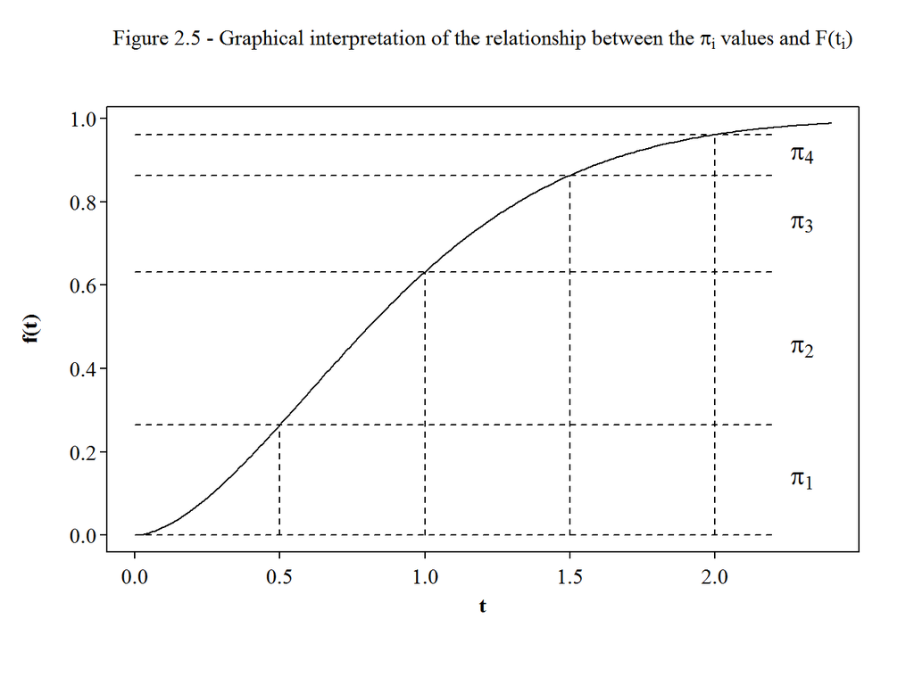

## Figure 2.5 - Relationship between $\pi_{i}$ and $F(t)$

STAT 687 - Chapter 2

```r
x<-seq(0,2.4,by=.01)
par(family="serif", font=2,bg=NA)
y<-function(t) {pweibull(t,shape=1.7,scale=1)}
plot(x, y(x), type="l",lwd=1.25,axes=FALSE,xlab="",ylab="")
segments(c(0,.5,1,1.5,2,rep(0,5)),c(rep(0,5),y(c(0.01,.5,1,1.5,2)))
        ,c(0,.5,1,1.5,2,rep(2.2,5)),rep(y(c(0.01,.5,1,1.5,2)),2),
        lty=rep(2,10),col=rep(1,10))
text(2.3,(y(0.5)+y(.01))/2,expression(pi[1]),cex=1.25)
text(2.3,(y(1.0)+y(0.5))/2,expression(pi[2]),cex=1.25)
text(2.3,(y(1.5)+y(1.0))/2,expression(pi[3]),cex=1.25)
text(2.3,(y(2.0)+y(1.5))/2,expression(pi[4]),cex=1.25)
box(lwd=1.25)
axis(side = 1, tck = -.015, labels = NA)
axis(side = 2, tck = -.015, labels = NA)
axis(side = 1, lwd = 0, line = -.6)
axis(side = 2, lwd = 0, line = -.6, las = 1)
mtext(side = 1, "t", line = 1.5)
mtext(side = 3,expression  (
  "Figure 2.5 - Graphical interpretation of the relationship between the "*pi[i]*" values and F("*t[i]*")",font=2  )  ,line = 2)
mtext(side = 2,"f(t)", line = 2.5)
```

## $\S$ - 2.2.1 Multinomial failure time model

STAT 687 - Chapter 2

**Differentiating between $i$ and $j$ in the text**

- $j$ denotes **any arbitrary interval**
- $i$ denotes **the interval of interest**

Therefore, the survival function evaluated at $t_{i}$ may be expressed as

$\displaystyle S(t_i)=P(T>t_i)=1-F(t_i)=\sum_{j=i+1}^{m+1}\pi_j$

Which means, in words…

> - The probability that a system will survive to inspection $i$ is the sum of the probabilities that the system is found to have failed at inspection $i+1$ or later

## Multinomial failure time model - example

STAT 687 - Chapter 2

Many A/C components cannot be inspected by base-level Mx due to lack of training, facilities, tools, etc.

- Components will only be inspected every $t$ flight-hours at the depot
- For each component, $\exists$ an underlying $F(t), t\in \mathcal{R}^{+}$ describing time to failure
- Form of $F(t)$ is often unknown, but may sometimes be inferred from similar components/systems

GOAL:

- Estimate risk of delaying replacement until next inspection (depot cycle)
- Balance safety risks against replacement costs

## Multinomial failure time model - example

STAT 687 - Chapter 2

Estimating the risk of delaying replacement until next inspection implies that

- The system has survived up to inspection $i-1$
- We want to know how likely it is that the system will fail before inspection $i$

The text defines this quantity in (2.7) as $p_{i}$

$\displaystyle p_i=P(t_{i-1}<T\le t_{i}|T>t_{i-1})=\frac{F(t_i)-F(t_{i-1})}{1-F(t_{i-1})}=\frac{\pi_{i}}{S(t_{i-1})}$

This is the **conditional** probability that the systems will fail prior to inspection $i$, given that it has survived to inspection $i-1$.

## $\S$ - 2.2.2 Multinomial cdf

STAT 687 - Chapter 2

From (2.7) we define the survival function in terms of $\mathbf{p}=(p_{1},...,p_{m})$ as

$\displaystyle S(t_{i})=\prod_{j=1}^{i}[1-p_{j}], i=1,...,m+1.$

Likewise

$\displaystyle F(t_{i})=1-\prod_{j=1}^{i}[1-p_{j}]=\sum_{j=1}^{i}[\pi_{j}], i=1,...,m+1.$

**YOUR TURN**  
**Describe, in words, what the above equation says**

## Table 2.1

STAT 687 - Chapter 2

| **$i$** | **$t_{i}$** | **$F(t_{i})$** | **$S(t_{i})$** | **$\pi_{i}$** | **$p_{i}$** | **$1-p_{i}$** |
| --- | --- | --- | --- | --- | --- | --- |
| 0 | 0.0 | 0.000 | 1.000 |  |  |  |
| 1 | 0.5 | 0.265 | 0.735 | 0.265 | 0.265 | 0.735 |
| 2 | 1.0 | 0.632 | 0.368 | 0.367 | 0.500 | 0.500 |
| 3 | 1.5 | 0.864 | 0.136 | 0.231 | 0.629 | 0.371 |
| 4 | 2.0 | 0.961 | .0388 | .0967 | 0.715 | 0.285 |
| 5 | $\infty$ | 1.000 | .0000 | .0388 | 1.000 | 0.000 |
|  |  |  |  | **1.000** |  |  |

# Section 2.3|Censoring

## $\S$ 2.3.1 - Censoring mechanisms

STAT 687 - Chapter 2

Censoring occurs when an outside event limits our ability to observe a failure time

**Type I Censoring** - Time censored samples

- Testing ends at a predetermined time
- The number of observed failures is a random quantity

**Type II Censoring** - Failure censored samples

- Testing ends after a predetermined number of failures
- The total test time is a random quantity

Modeling Type II censored data is simpler than for Type I data

Failure censored tests (Type II) are far less common than time-censored tests

**Why are these two statements true?**

## $\S$ 2.3.1 - Type I vs. Type II censoring

STAT 687 - Chapter 2

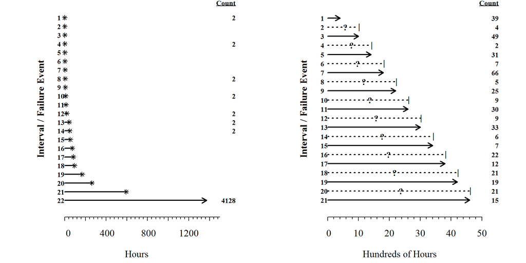

## $\S$ 2.3.1 - Type I vs. Type II censoring

STAT 687 - Chapter 2

```r
###<b>
par(mfrow=c(1,2),family="serif",font=2,bg=NA)
###</b>
lfp1370.ld <- frame.to.ld(lfp1370,
                          response.column = 1,
                          censor.column = 2,
                          case.weight.column = 3,
                          data.title = "Integrated Circuit Failure Data After 1370 Hours",
                          time.units = "Hours")
###<b>
event.plot(lfp1370.ld)
###</b>
turbine.ld <- frame.to.ld(turbine,
                          response.column = 1,
                          censor.column = 2,
                          case.weight.column = 3,
                          data.title = "Turbine Wheel Crack Initiation Data",
                          time.units = "Hundreds of Hours")
###<b>
event.plot(turbine.ld)
```

```r
par(mfrow=c(1,1))
###</b>
```

## $\S$ 2.3.1 - Censoring mechanisms

STAT 687 - Chapter 2

Time censored test data (Type I) may be further sub-divided according to

**The number of censoring events**

- Singly censored
- Multiply censored

**The contribution to the likelihood function $\S$ 2.4**

- Right censored
- Left censored
- Interval censored

> Recall…**ALL DATA IS INTERVAL DATA**

## $\S$ 2.3.2 - Assumptions on censoring mechanisms

STAT 687 - Chapter 2

This course considers censoring events that are **independent** of the time to failure

- Test ends before all samples have failed
- Sample removed from test to fill a real-world need
- Secondary failure mode occurs
- Sample fails before first inspection

Competing risks considers **dependent** censoring events that affect time to failure

- Common in medical survivability research
- Beyond the scope of this course

# Section 2.4|Likelihood

## $\S$ 2.4.1 - Likelihood-based statistical methods

STAT 687 - Chapter 2

Say that we observe $DATA = t_{1},t_{2},...,t_{n}$

If these observations were produced by units that can reasonably be considered as identical, then

$t_{1},t_{2},...,t_{n} \sim i.i.d. F(t|\mathbf{\theta}=\theta_{1},...,\theta_{n})$

The form of $F(t|\mathbf{\theta})$ and the values of $\theta_{1},...,\theta_{n}$ are unknown, but likelihood theory states

- For each distribution family, we can find $\mathbf{\theta}$ such that

$\displaystyle \mathcal{L_i}(\theta|data_i)=f(data_i|\theta)=\prod_{i=1}^{n}f(x_{i}|\theta)$

## $\S$ 2.4.1 - Likelihood-based statistical methods

STAT 687 - Chapter 2

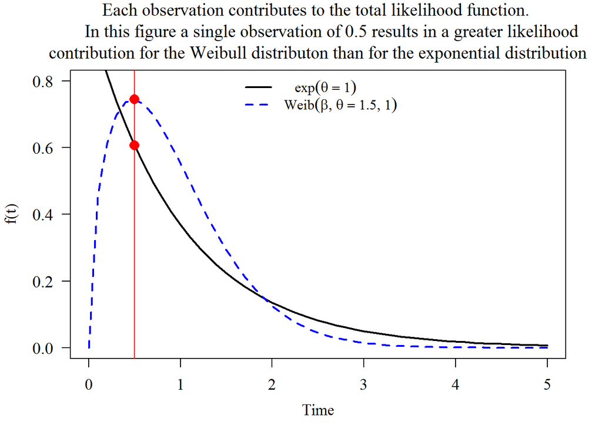

## $\S$ 2.4.1 - Likelihood-based statistical methods

STAT 687 - Chapter 2

```r
par(bg = NA, family = "serif")
x<-seq(0,5,.1)
plot(x,dexp(x, rate = 1), type = "l", lwd=2, col = 1,
     yaxt = "n", xaxt = "n", xlab = "", ylab = "", ylim = range(0,.8))
par(new = TRUE)
plot(x,dweibull(x, shape = 1.5), type = "l", lwd=2, col = 4,
     yaxt = "n", xlab = "", ylab = "", cex.axis = 1.1, ylim = range(0,0.8), lty = 2)
points(x = c(0.5,0.5),y = c(dexp(0.5, rate = 1), dweibull(0.5,shape = 1.5)),
       cex=1.5, pch = 16, col = 2)
axis(side = 2, las = 1, cex.axis = 1.15)
abline(v = 0.5, col = 2)
legend("top",c(parse(text = "~~~exp(theta==1)"),parse(text = "Weib(beta,theta==1.5,1)")),
       lwd = 2, col = c(1,4), bty = "n", lty = c(1,2))
mtext(side = 1, "Time", cex = 1.1, line = 2.5)
mtext(side = 2, "f(t)", cex = 1.1, line = 3)
mtext(side = 3, "Each observation contributes to the total likelihood function.
      In this figure a single observation of 0.5 results in a greater likelihood
contribution for the Weibull distributon than for the exponential distribution", line = 0.5, cex = 1.25)
```

## $\S$ 2.4.1 - Likelihood-based statistical methods

STAT 687 - Chapter 2

Thus, the value of the total likelihood function is equal to the joint probability of the data $\displaystyle \mathscr{L}(\theta|DATA)=C\prod_{i=1}^{n} \mathcal{L}_{i}(\theta|data_i)$

Note that

- $\mathcal{L_i}(\theta|data_i)$ - function of the parameter set $\theta$ assuming we observe $data_i$
- $\prod_{i=1}^{n}f(x_{i}|\theta)$ - function of $data_i$ assuming $\theta$ is known

Idea is to maximize the likelihood of observing $DATA$ based on two inputs:

- An assumed probability model ($f(x)$)
- A set of parameter values ($\mathbf{\theta}=\theta_{1},...,\theta_{n}$)

## $\S$ 2.4.3 - Contributions to the likelihood function

STAT 687 - Chapter 2

Every item in the sample set under evaluation contributes to the total likelihood

For an underlying failure distribution $F(t)$, the value of $\mathcal{L}_i$ for a censored observation is

**$\text{Table 2.2 - Likelihood contributions for life-table data}$**

| Censoring type | Range | Likelihood |
| --- | --- | --- |
| $d_{i}$ observations interval censored in $t_{i-1}$ and $t_{i}$ | $t_{i-1}<T\le t_{i}$ | $[F(t_{i})-F(t_{i-1})]^{d_{i}}$ |
| $l_{i}$ observations left censored at $t_{i}$ | $T\le t_{i}$ | $[F(t_{i})]^{l_{i}}$ |
| $r_{i}$ observations right censored at $t_{i}$ | $T>t_{i}$ | $[1-F(t_{i})]^{r_{i}}$ |

## Figure 2.6 - Likelihood contributions

STAT 687 - Chapter 2

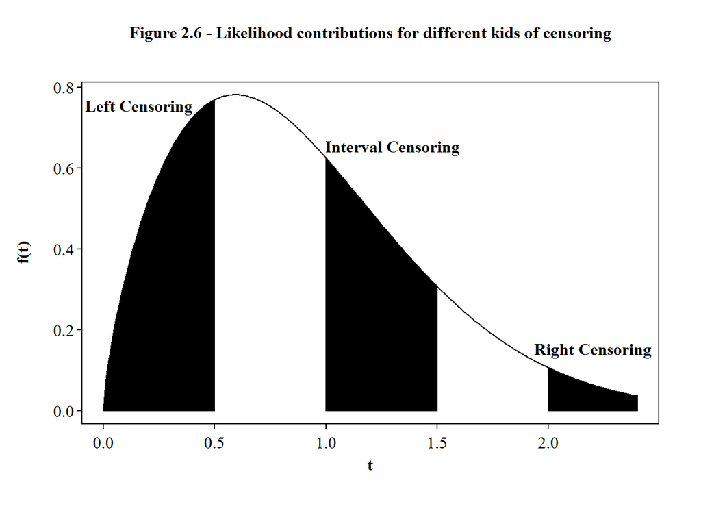

## Figure 2.6 - Likelihood contributions

STAT 687 - Chapter 2

```r
x<-seq(0,2.4,by=.01)
par(family="serif", font=2,bg=NA)
y<-dweibull(seq(0,2.4,by=.01),shape=1.7,scale=1)
plot(x, y, type="l",lwd=1.25,axes=FALSE)
polygon(c(seq(0,.5,.01),.5),c(dweibull(seq(0,.5,.01),sh=1.7,sc=1),0),col="black")
polygon(c(1,seq(1,1.5,.01),1.5),c(0,dweibull(seq(1,1.5,.01),sh=1.7,sc=1),0),col="black")
polygon(c(2,seq(2,2.4,.01),2.4),c(0,dweibull(seq(2,2.4,.01),sh=1.7,sc=1),0),col="black")
text(.16,.75,"Left Censoring")
text(1.3,.65,"Interval Censoring")
text(2.2,.15,"Right Censoring")
box(lwd=1.25)
axis(side = 1, tck = -.015, labels = NA); axis(side = 2, tck = -.015, labels = NA)
axis(side = 1, lwd = 0, line = -.6);      axis(side = 2, lwd = 0, line = -.6, las = 1)
mtext(side = 1, "t", line = 1.5)
mtext(side = 3,"Figure 2.6 - Likelihood contributions for different kids of censoring",
      line = 2)
mtext(side = 2,"f(t)", line = 2.5)
```

## $\S$ 2.4.3 - Contributions to the likelihood function

STAT 687 - Chapter 2

The total likelihood function may therefore be expressed as

$\begin{aligned} \mathscr{L}(\theta|DATA)&=C\prod_{i=1}^{n} \mathcal{L}_{i}(\theta|data_i)\\ &=C\prod_{i=1}^{m+1}[F(t_{i})]^{l_{i}}[F(t_{i})-F(t_{i-1})]^{d_{i}}[1-F(t_{i})]^{r_{i}} \end{aligned}$

where $n = \sum_{j=1}^{m+1}(d_{j}+r_{j}+l_{j})$

## $\S$ 2.4.4 - Form of the constant term $C$

STAT 687 - Chapter 2

In general,the multinomial constant term $C$ does not effect the parameter values that maximize the likelihood function

For most models used in this course $C$ may be considered a proportionality constant (i.e. $C=1$)

$\mathcal{C}=\frac{n!}{d_1!...d_{m+1}!}$

## $\S$ 2.4.5 - Likelihood for General Reliability Data

STAT 687 - Chapter 2

This section presents a more general expression for the total likelihood function when

- The intervals in which a failure occurs overlap
- The union of the intervals down not cover the entire time line $(0,\infty)$

In this course, the form of $\mathscr{L}$ given in equation 2.14 is sufficient

## $\S$ 2.4.6 - Other Likelihood Terms

STAT 687 - Chapter 2

This section presents an even more general expression for the total likelihood function when

- Censoring occurs at random times within the intervals according to $f_{c}(t)$
- The distributions represented by $f_{c}(t)$ and $f(t)$ are independent

This occurs is multiple failure modes are present in the unit under test

Multiple failure modes with be considered in Chapter 15

Truncated data will be discussed in Chapter 11